# Data Analysis for Experiments 1 and 2

2024-08-13

# Introduction

In this document, we present the complete analysis for the paper `More ’pacas, More Problems: How Uncertainty Representations for Multiple Forecasts Impact Decision Making`. In this paper, we conducted three separate experiments:

- in Experiment 1, we compare ensembles and p-boxes
- in Experiment 2, we compare two different ensembles (left and right skewed)
- in Experiment 3, we compare phrasing (reliable vs equally reliable) to address an error in Experiment 1

# Experiment 1

We first load the (anonymised) data for experiment 1, to which we add the relevant experimental parameters (from the `exp.design` data frame):

```r
df_exp1 = read.csv("../data/study-final-1/anonymised-data.csv") |>
  select(-c(curve_for_decision:budget)) |>
  mutate(block = factor(block, levels = c("single", "multiple"))) |>
  left_join(
    rename(exp.design, trial = index), # in exp.design, index indicates the trial id
    by = c("block", "trial")
  ) |>
  filter(trial < 100)  # remove attention check trials

head(df_exp1)
```

```
##    user_id       vis index  block response trial   mu       sd
## 1 1fd3fed4 ensembles     1 single        1     2   30 2.045473
## 2 1fd3fed4 ensembles     2 single        0     8   33 1.890241
## 3 1fd3fed4 ensembles     3 single        0    15 36.5 2.140116
## 4 1fd3fed4 ensembles     5 single        0     9 33.5     2.08
## 5 1fd3fed4 ensembles     6 single        0    14   36 2.133972
## 6 1fd3fed4 ensembles     7 single        0    11 34.5 1.976972
##                  dist     p_true     .upper     .lower
## 1 30.000000, 2.045473  0.8359057 0.83590565 0.83590565
## 2 33.000000, 1.890241  0.2983912 0.29839124 0.29839124
## 3 36.500000, 2.140116 0.01774644 0.01774644 0.01774644
## 4         33.50, 2.08  0.2354074 0.23540743 0.23540743
## 5 36.000000, 2.133972 0.03043499 0.03043499 0.03043499
## 6 34.500000, 1.976972  0.1030145 0.10301453 0.10301453
```

The resultant dataset has the following schema:

- `user_id`: A unique identifier which is assigned to each user
- `vis`: the visualisation condition that the user was in
- `index`: trial index
- `block`: the block associated with the trial (`single` or `multiple`)
- `response`: participants’ response; 1: send aid; 0: do not send aid
- `trial`: the trial index associated with the stimuli
- `mu`: mean(s) of the forecasts shown to participants
- `sd`: sd(s) of the forecasts shown to participants
- `dist`: distributional objects(s) for each of the forecasts shown to participants
- `p_true`: probability of freezing corresponding to each of the forecasts
- `.upper`: upper bound of the probability of freezing corresponding to each of the forecasts
- `.lower`: lower bound of the probability of freezing corresponding to each of the forecasts

## Exploratory Data Analysis

We find that the best way to visualise the data is to show the responses of a sample of participants. Below, are the responses for the block where single forecasts are shown:

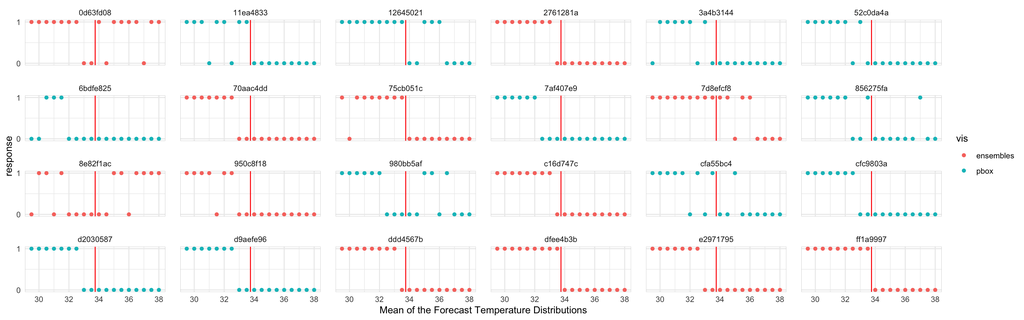

```r
df_exp1.sample = df_exp1 |>
  group_by(user_id, vis) |>
  nest() |>
  group_by(vis) |>
  sample_n(12) |>
  unnest(c(data))

df_exp1.sample |>
  filter(block == "single") |>
  unnest(c(mu)) |>
  ggplot() +
  geom_vline(aes(xintercept = 33.75), colour = "red") +
  geom_point(aes(x = mu, y = response, colour = vis)) +
  facet_wrap(. ~ user_id, nrow = 4) +
  scale_y_continuous(breaks = c(0, 1)) +
  labs(x = "Mean of the Forecast Temperature Distributions") +
  theme(panel.border = element_rect(colour = "#bbbbbb", fill = NA, linewidth = 0.2), panel.spacing = unit(6, "mm"))
```

Below, are the responses for the block where multiple forecasts are shown:

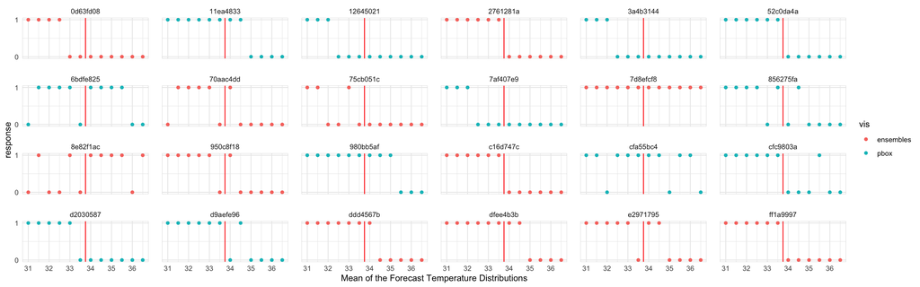

```r
df_exp1.sample |>
  filter(block == "multiple") |>
  mutate(mu = map_dbl(mu, ~ .[[4]])) |>
  ggplot() +
  geom_vline(aes(xintercept = 33.75), colour = "red") +
  geom_point(aes(x = mu, y = response, colour = vis)) +
  facet_wrap(. ~ user_id, nrow = 4) +
  scale_y_continuous(breaks = c(0, 1)) +
  labs(x = "Mean of the Forecast Temperature Distributions") +
  theme(panel.border = element_rect(colour = "#bbbbbb", fill = NA, linewidth = 0.2), panel.spacing = unit(6, "mm"))
```

## Modeling

We use the model outlined in `03-simulation.Rmd`, where we described in detail our progressive model building approach. The first step is to fit the model:

```r
df_exp1_all_forecast.list = df_exp1 |>
  prepare_standata_study1(.id = "user_id") |>
  add_list_vars(
    "X" = matrix(as.integer(c(df_exp1$vis == "pbox", df_exp1$vis == "ensembles")), ncol = 2),
    K = 2,
    M = 2
  )

model_all_forecasts = cmdstan_model("./stan_models/03-model-complete_forecasts-all_effects.stan")
```

```r
if (FLAG_RUN_MODEL) {
  fit_final_exp1 = model_all_forecasts$sample(
      data = df_exp1_all_forecast.list,
      iter_warmup = 4000,
      iter_sampling = 4000,
      chains = 4,
      parallel_chains = 4,
      refresh = 400,
      thin = 4
    )

  # draws.fit_exp1 = as_draws_df(fit_final_exp1)
  # saveRDS(fit_final_exp1, "../cache/_model_fits/04-fit_final_study1.rds")
} else {
  fit_final_exp1 = readRDS("../cache/_model_fits/04-fit_final_study1.rds")
}
```

## Diagnostics

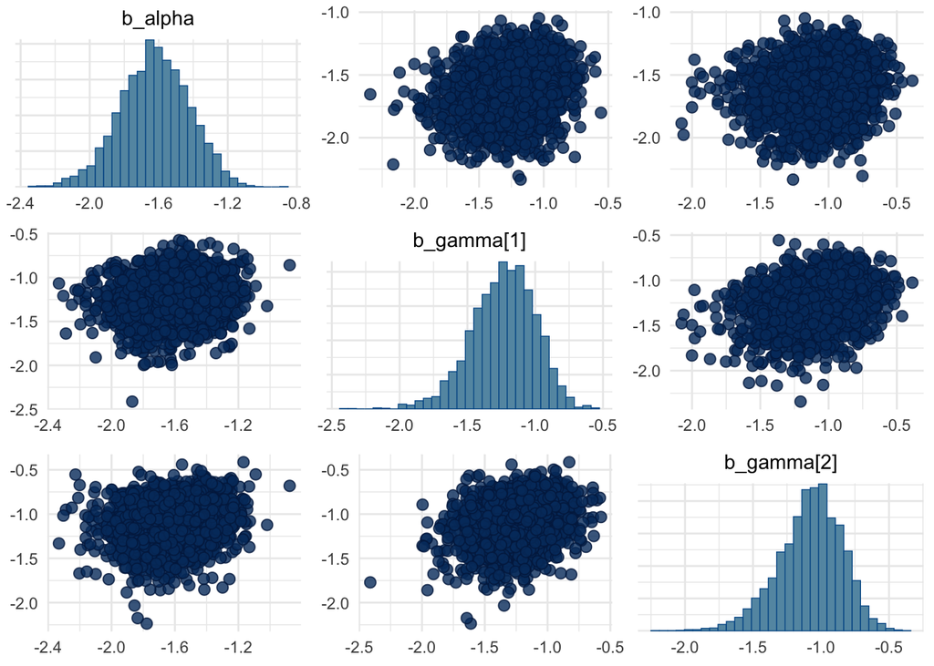

```r
as_draws(fit_final_exp1) |>
  bayesplot::mcmc_pairs(pars = c("b_alpha", "b_gamma[1]", "b_gamma[2]"))
```

## Results

Below, we extract draws and show the posterior mean and 95% credible intervals for each of the parameters.

```r
draws.fit_exp1 = as_draws_df(fit_final_exp1)

draws.fit_exp1 |>
  select(-starts_with("r"), -starts_with("z"), -starts_with("sd"), -starts_with("L")) |>
  mutate(
    gamma1 = map_dbl(`b_gamma[1]`, gtools::inv.logit),
    gamma2 = map_dbl(`b_gamma[2]`, gtools::inv.logit)
  ) |>
  summarise_draws(mean, sd, quantile2, rhat, ess_bulk, ess_tail) |>
  mutate_if(is.numeric, ~ round(., 2))
```

```
## # A tibble: 6 × 8
##   variable    mean    sd    q5   q95  rhat ess_bulk ess_tail
##   <chr>      <dbl> <dbl> <dbl> <dbl> <dbl>    <dbl>    <dbl>
## 1 b_beta      2.86  0.2   2.55  3.2      1    2518.    3061.
## 2 b_alpha    -1.62  0.2  -1.96 -1.3      1    2109.    2922.
## 3 b_gamma[1] -1.24  0.24 -1.64 -0.88     1    3079.    3072.
## 4 b_gamma[2] -1.08  0.24 -1.5  -0.74     1    3136.    3406.
## 5 gamma1      0.23  0.04  0.16  0.29     1    3079.    3072.
## 6 gamma2      0.26  0.04  0.18  0.32     1    3136.    3406.
```

To visualise the results, we show the posterior densities for $\alpha$ and $\beta$ parameters as well as the estimated linear relationship between the probability of freezing shown for a forecast and the probability of sending aid. We also show the posterior densities for the $\gamma$ parameters in the two conditions, and estimate a `decision-making reference distribution corresponding` to the value of $\gamma$: assuming participants are applying the optimism-pessimism rule for making decision, what distribution does their weight correspond to?

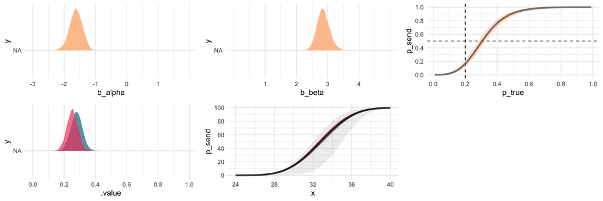

```r
df_exp1_parameters = draws.fit_exp1 |>
  spread_draws(b_alpha, b_beta, b_gamma[vis], sd_gamma) |>
  mutate(
    .value = map2_dbl(b_gamma, sd_gamma, ~ logitnorm::momentsLogitnorm(mu = .x, sigma = .y)[[1]]),
  ) |>
  select(-b_gamma, -sd_gamma) |>
  pivot_wider(values_from = .value, names_from = "vis", names_prefix = "b_gamma_")

df_exp1_pbox = tibble(
  x = seq(xlims[1], xlims[2], by = 0.1),
  .lower = map_dbl(x, ~ cdf(dist_normal(32, 2.34), .x)[[1]]*100),
  .upper = map_dbl(x, ~ cdf(dist_normal(35, 2.01), .x)[[1]]*100)
)

p1 = df_exp1_parameters |>
  ggplot() +
  stat_slab(aes(x = b_alpha, y = NA), fill = "#FFC49B") +
  scale_x_continuous(breaks = seq(-3, 1, by = 1), limits = c(-3, 2))

p2 = df_exp1_parameters |>
  ggplot() +
  stat_slab(aes(x = b_beta, y = NA), fill = "#FFC49B") +
  scale_x_continuous(breaks = seq(1, 4, by = 1), limits = c(0, 5))

p3 = draws.fit_exp1 |>
  spread_draws(b_alpha, b_beta) |>
  mutate(p_true = list(seq(0.01, 0.99, by = 0.01))) |>
  unnest(c(p_true)) |>
  mutate(p_send = inv.logit(b_alpha + b_beta * (logit(p_true) - logit(0.2)))) |>
  ggplot()+
  geom_vline(xintercept = 0.2, lty = 2) +
  geom_hline(yintercept = 0.5, lty = 2) +
  stat_lineribbon(aes(x = p_true, y = p_send), .width = 0.95, fill = "#FFC49B", alpha = 0.5) +
  scale_x_continuous(breaks = seq(0, 1, by = 0.2)) +
  scale_y_continuous(breaks = seq(0, 1, by = 0.2))

p4 = df_exp1_parameters |>
  pivot_longer(cols = starts_with("b_"), names_pattern = "b_(.*)", names_to = "parameter", values_to = ".value") |>
  filter(parameter == "gamma_1" | parameter == "gamma_2") |>
  ggplot() +
  stat_slab(aes(x = .value, y = NA, fill = parameter), alpha = 0.7) +
  # scale_x_continuous(breaks = seq(-4, 2, by = 2), limits = c(-5, 4)) +
  scale_x_continuous(breaks = seq(0, 1, by = 0.2), limits = c(0, 1)) +
  theme(legend.position = "none") +
  scale_fill_manual(values = pallete1)

p5 = df_exp1_parameters |>
  select(-b_alpha, -b_beta) |>
  mutate(data = list(filter(df_exp1_pbox, x >= 24 & x <= 40))) |>
  unnest(c(data)) |>
  pivot_longer(cols = starts_with("b_"), names_pattern = "b_(.*)", names_to = "parameter", values_to = ".value") |>
  mutate(p_send = .value *.upper + (1 - .value)*.lower) |>
  ggplot() +
  geom_lineribbon(data = filter(df_exp1_pbox, x >= 24 & x <= 40), aes(x = x, ymin = .lower, ymax = .upper), fill = "#aaaaaa", alpha = 0.2, linewidth = 0.15) +
  stat_lineribbon(aes(x, p_send, fill = parameter), .width = .95, alpha = 0.5) +
  scale_x_continuous(breaks = seq(24, 40, by = 4)) +
  scale_y_continuous(breaks = seq(0, 100, by = 20)) +
  theme(legend.position = "none") +
  scale_fill_manual(values = pallete1)

# pdf(file = "../figures/paper/study1-parameters.pdf", useDingbats = FALSE, width = 16, height = 6)
cowplot::plot_grid(p1, p2, p3, p4, p5, NULL, nrow = 2)
```

```r
# dev.off()
```

### Estimate of the crossover point

Our generative model also allows us to derive an estimate (with uncertainty) for the crossover point:

```r
draws.fit_exp1 |>
  spread_draws(b_alpha, b_beta) |>
  mutate(p = inv.logit((logit(0.5) - b_alpha) / b_beta + logit(0.2))) |>
  median_qi(p, .width = .95)
```

```
## # A tibble: 1 × 6
##       p .lower .upper .width .point .interval
##   <dbl>  <dbl>  <dbl>  <dbl> <chr>  <chr>
## 1 0.306  0.284  0.329   0.95 median qi
```

### Difference in gamma

We also estimate the difference in $\gamma$ between the two conditions:

```r
df_exp1_parameters |>
  mutate(.diff = b_gamma_1 - b_gamma_2) |>
  median_qi(.diff)
```

```
## # A tibble: 1 × 6
##     .diff .lower .upper .width .point .interval
##     <dbl>  <dbl>  <dbl>  <dbl> <chr>  <chr>
## 1 -0.0265 -0.121 0.0701   0.95 median qi
```

### Random effects for gamma

We incorporate a hierarchical model where we estimate a separate intercept parameter for each participant

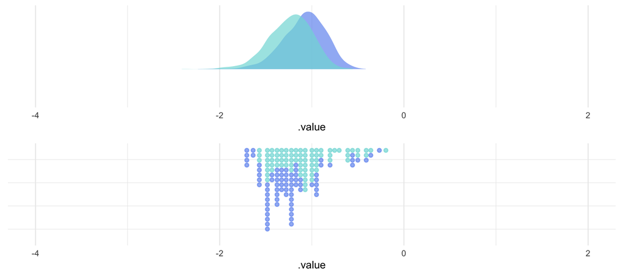

```r
df_exp1_conditions = df_exp1 |>
  select(user_id, vis) |>
  group_by(user_id) |>
  filter(row_number() == 1) |>
  ungroup() |>
  mutate(
    user_id = as.integer(factor(user_id)),
    vis = ifelse(vis == "pbox", 1, 2)
  )

df_exp1.draws_gamma = draws.fit_exp1 |>
  spread_draws(b_gamma[vis], r_gamma[user_id], ndraws = 2000) |>
  right_join(df_exp1_conditions, by = join_by(vis, user_id)) |>
  group_by(vis, user_id) |>
  mutate(
    .value = b_gamma + r_gamma,
    .mean = mean(.value),
    vis = ifelse(vis == 1, "pbox", "ensembles"),
  ) |>
  arrange(.mean) |>
  nest() |>
  group_by(vis) |>
  mutate(.index = row_number(), .index = factor(.index)) |>
  unnest(c(data)) |>
  select(-b_gamma, -r_gamma, -.chain, -.iteration)

p.exp1.gamma_fixedeffs = draws.fit_exp1 |>
  spread_draws(b_gamma[vis], sd_gamma, ndraws = 2000) |>
  mutate(
    .value = b_gamma,
    vis = factor(ifelse(vis == 1, "ensembles_left", "ensemble_right"), levels = c("ensembles_left", "ensemble_right"))
  ) |>
  ggplot() +
  geom_hline(yintercept = 0, linewidth = 0.25) +
  stat_slab(aes(y = NA, x = .value, fill = vis), alpha = 0.7, orientation = "y") +
  scale_fill_manual(values = pallete2) +
  scale_colour_manual(values = pallete2) +
  coord_cartesian(xlim = c(-4, 2)) +
  theme(legend.position = "none", axis.text.y = element_blank(), panel.grid.major.y = element_blank(), axis.title.y = element_blank())

p.exp1.gamma_dots = df_exp1.draws_gamma |>
  group_by(vis, user_id) |>
  summarise(.value = mean(.value), .groups = "keep") |>
  ggplot() +
  # geom_dots(aes(x = .value, fill = vis, colour = vis), alpha = 0.7, side = "bottomleft", dotsize = 1.075, overflow = "keep") +
  geom_dots(
    aes(x = .value, fill = vis, colour = vis, group = NA, order = vis),
    alpha = 0.7, side = "bottomleft", dotsize = 1.075, overflow = "keep"
  ) +
  scale_fill_manual(values = pallete2) +
  scale_colour_manual(values = pallete2) +
  coord_cartesian(xlim = c(-4, 2)) +
  theme(legend.position = "none", axis.text.y = element_blank(), panel.grid.major.y = element_blank())

# pdf(file = "../figures/paper/study2-gamma.pdf", useDingbats = FALSE, width = 8, height = 10)
cowplot::plot_grid(p.exp1.gamma_fixedeffs, p.exp1.gamma_dots, ncol = 1)
```

```r
# dev.off()
```

From the figure above, we do not observe much variation between participants.

The results of Experiment 1 suggests that there is likely little or no difference in participants’ decision-making strategies when a set of uniformly distributed multiple forecasts are presented either as ensembles or p-boxes. However, it is possible that forecasts are not always going to be uniformly distributed. In Experiment 2, we explore whether a clustering of forecasts (which we refer to as left-skewed or right-skewed ensembles) could have an impact on participants’ decision-making strategies.

# Experiment 2

To analyse the data for Experiment 2, we repeat the steps outlined for Experiment 1.

```r
df_exp2 = read.csv("../data/study-final-2/anonymised-data.csv") |>
  mutate(block = factor(block, levels = c("single", "multiple"))) |>
  left_join(
    rename(exp.design, trial = index), # in exp.design, index indicates the trial id
    by = c("block", "trial")
  ) |>
  filter(trial < 100)

head(df_exp2)
```

```
##             StartDate             EndDate     Status Progress Finished
## 1 2024-08-30 12:59:41 2024-08-30 13:02:44 IP Address      100     True
## 2 2024-08-30 12:59:41 2024-08-30 13:02:44 IP Address      100     True
## 3 2024-08-30 12:59:41 2024-08-30 13:02:44 IP Address      100     True
## 4 2024-08-30 12:59:41 2024-08-30 13:02:44 IP Address      100     True
## 5 2024-08-30 12:59:41 2024-08-30 13:02:44 IP Address      100     True
## 6 2024-08-30 12:59:41 2024-08-30 13:02:44 IP Address      100     True
##          RecordedDate        ResponseId DistributionChannel UserLanguage
## 1 2024-08-30 13:02:45 R_7lz8NquEdwpXpl8           anonymous           EN
## 2 2024-08-30 13:02:45 R_7lz8NquEdwpXpl8           anonymous           EN
## 3 2024-08-30 13:02:45 R_7lz8NquEdwpXpl8           anonymous           EN
## 4 2024-08-30 13:02:45 R_7lz8NquEdwpXpl8           anonymous           EN
## 5 2024-08-30 13:02:45 R_7lz8NquEdwpXpl8           anonymous           EN
## 6 2024-08-30 13:02:45 R_7lz8NquEdwpXpl8           anonymous           EN
##   Q_RecaptchaScore browser version        os consent curve.for.decision
```

[output cut: 55 more lines]

## Modelling

```r
df_exp2_all_forecast.list = df_exp2 |>
  prepare_standata_study1(.id = "user_id") |>
  add_list_vars(
    K = 2,
    M = 2,
    "X" = matrix(as.integer(c(df_exp2$vis == "ensembles_left", df_exp2$vis == "ensembles_right")), ncol = 2)
  )

model_all_forecasts = cmdstan_model("./stan_models/03-model-complete_forecasts-all_effects.stan")
```

```r
if (FLAG_RUN_MODEL) {
  fit_final_exp2 = model_all_forecasts$sample(
    data = df_exp2_all_forecast.list,
    iter_warmup = 4000,
    iter_sampling = 4000,
    chains = 4,
    parallel_chains = 4,
    refresh = 400,
    thin = 4
  )

  # draws.fit_exp2 = as_draws_df(fit_final_exp2)
  # saveRDS(fit_final_exp2, "../cache/_model_fits/05-fit_final_study2.rds")
} else {
  fit_final_exp2 = readRDS("../cache/_model_fits/05-fit_final_study2.rds")
}
```

### Diagnostics

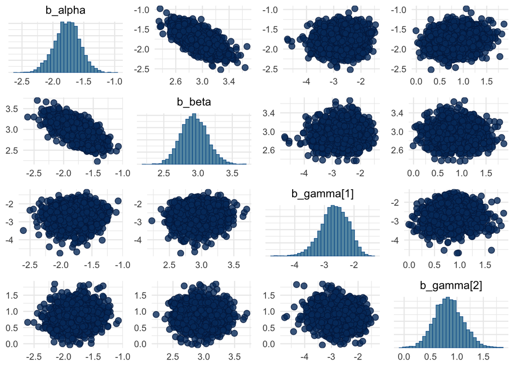

```r
as_draws(fit_final_exp2) |>
  bayesplot::mcmc_pairs(pars = c("b_alpha", "b_beta", "b_gamma[1]", "b_gamma[2]"))
```

### Results

```r
draws.fit_exp2 = as_draws_df(fit_final_exp2)

draws.fit_exp2 |>
  select(-starts_with("r"), -starts_with("z"), -starts_with("sd"), -starts_with("L")) |>
  mutate(
    gamma1 = map_dbl(`b_gamma[1]`, gtools::inv.logit),
    gamma2 = map_dbl(`b_gamma[2]`, gtools::inv.logit)
  ) |>
  summarise_draws(mean, sd, quantile2, rhat, ess_bulk, ess_tail) |>
  mutate_if(is.numeric, ~ round(., 2))
```

```
## # A tibble: 6 × 8
##   variable    mean    sd    q5   q95  rhat ess_bulk ess_tail
##   <chr>      <dbl> <dbl> <dbl> <dbl> <dbl>    <dbl>    <dbl>
## 1 b_beta      2.94  0.19  2.63  3.27     1    3236.    3630.
## 2 b_alpha    -1.77  0.21 -2.12 -1.44     1    2932.    3409.
## 3 b_gamma[1] -2.66  0.46 -3.46 -1.95     1    3793.    4012.
## 4 b_gamma[2]  0.85  0.28  0.41  1.31     1    3823.    3682.
## 5 gamma1      0.07  0.03  0.03  0.12     1    3793.    4012.
## 6 gamma2      0.7   0.06  0.6   0.79     1    3823.    3682.
```

```r
df_exp2_conditions = df_exp2 |>
  select(user_id, vis) |>
  group_by(user_id) |>
  filter(row_number() == 1) |>
  ungroup() |>
  mutate(
    user_id = as.integer(factor(user_id)),
    vis = ifelse(vis == "ensembles_left", 1, 2)
  )

df_exp2.draws_gamma = draws.fit_exp2 |>
  spread_draws(b_gamma[vis], r_gamma[user_id], ndraws = 2000) |>
  right_join(df_exp2_conditions, by = join_by(vis, user_id)) |>
  group_by(vis, user_id) |>
  mutate(
    .value = b_gamma + r_gamma,
    # .value = inv.logit(b_gamma + r_gamma),
    vis = ifelse(vis == 1, "ensembles_left", "ensembles_right"),
  ) |>
  select(-b_gamma, -r_gamma, -.chain, -.iteration)
```

### Gamma parameter

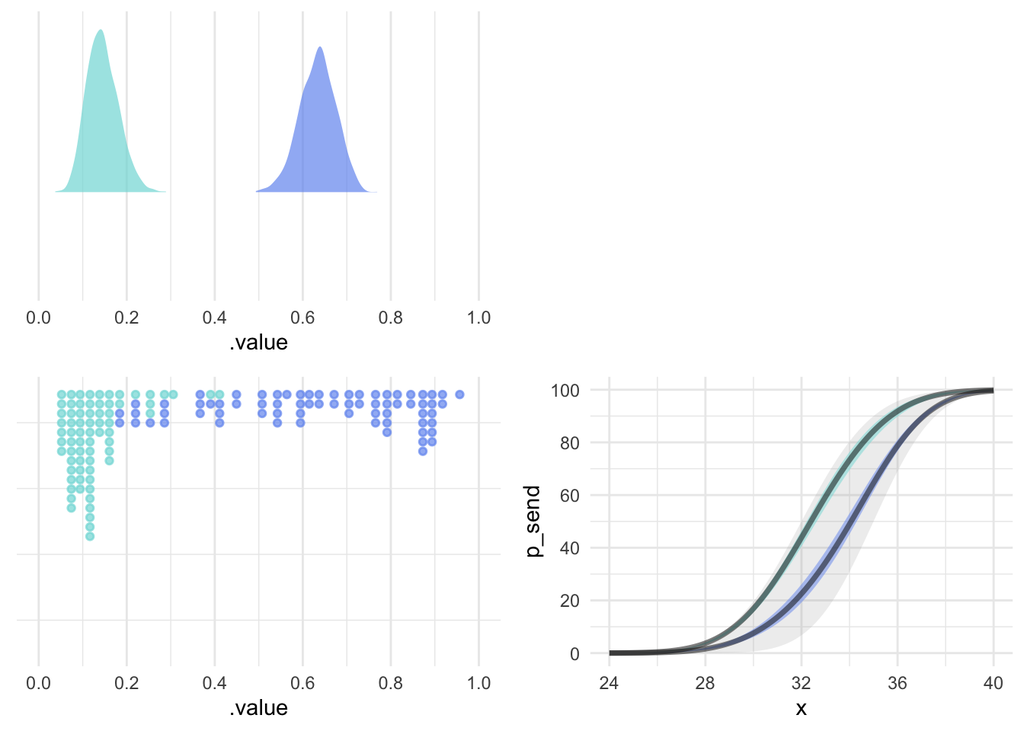

```r
df_exp2_parameters = draws.fit_exp2 |>
  spread_draws(b_alpha, b_beta, b_gamma[vis], sd_gamma) |>
  mutate(
    .value = map2_dbl(b_gamma, sd_gamma, ~ logitnorm::momentsLogitnorm(mu = .x, sigma = .y)[[1]]),
  ) |>
  select(-b_gamma, -sd_gamma) |>
  pivot_wider(values_from = .value, names_from = "vis", names_prefix = "b_gamma_")

p.exp2.gamma_fixedeffs = draws.fit_exp2 |>
  spread_draws(b_gamma[vis], sd_gamma, ndraws = 2000) |>
  mutate(
    .value = map2_dbl(b_gamma, sd_gamma, ~ logitnorm::momentsLogitnorm(mu = .x, sigma = .y)[[1]]),
    vis = factor(ifelse(vis == 1, "ensembles_left", "ensemble_right"), levels = c("ensembles_left", "ensemble_right"))
  ) |>
  ggplot() +
  geom_hline(yintercept = 0, linewidth = 0.25) +
  stat_slab(aes(y = NA, x = .value, fill = vis), alpha = 0.7, orientation = "y") +
  scale_fill_manual(values = pallete2) +
  scale_colour_manual(values = pallete2) +
  scale_x_continuous(breaks = seq(0, 1, by = 0.2)) +
  coord_cartesian(xlim = c(0, 1)) +
  theme(legend.position = "none", axis.text.y = element_blank(), panel.grid.major.y = element_blank(), axis.title.y = element_blank())

p.exp2.gamma_dots = df_exp2.draws_gamma |>
  group_by(vis, user_id) |>
  summarise(.value = mean(inv.logit(.value)), .groups = "keep") |>
  ggplot() +
  geom_dots(
    aes(x = .value, fill = vis, colour = vis, group = NA, order = vis),
    binwidth = 0.02, alpha = 0.7, side = "bottomleft", dotsize = 1.075, overflow = "keep"
  ) +
  scale_fill_manual(values = pallete2) +
  scale_colour_manual(values = pallete2) +
  scale_x_continuous(breaks = seq(0, 1, by = 0.2)) +
  coord_cartesian(xlim = c(0, 1)) +
  theme(legend.position = "none", axis.text.y = element_blank(), panel.grid.major.y = element_blank())

p5.gamma = df_exp2_parameters |>
  select(-b_alpha, -b_beta) |>
  mutate(data = list(filter(df_exp1_pbox, x >= 24 & x <= 40))) |>
  unnest(c(data)) |>
  pivot_longer(cols = starts_with("b_"), names_pattern = "b_(.*)", names_to = "parameter", values_to = ".value") |>
  mutate(p_send = .value *.upper + (1 - .value)*.lower) |>
  ggplot() +
  geom_lineribbon(data = filter(df_exp1_pbox, x >= 24 & x <= 40), aes(x = x, ymin = .lower, ymax = .upper), fill = "#aaaaaa", alpha = 0.2, linewidth = 0.15) +
  stat_lineribbon(aes(x, p_send, fill = parameter), .width = .95, alpha = 0.5) +
  scale_x_continuous(breaks = seq(24, 40, by = 4)) +
  scale_y_continuous(breaks = seq(0, 100, by = 20)) +
  theme(legend.position = "none") +
  scale_fill_manual(values = pallete2)

# pdf(file = "../figures/paper/study2-gamma.pdf", useDingbats = FALSE, width = 8, height = 5)
cowplot::plot_grid(p.exp2.gamma_fixedeffs, NULL, p.exp2.gamma_dots, p5.gamma, ncol = 2)
```

```r
# dev.off()
```

## Comparison to Padilla et al.

Our study is similar to the study conducted by Padilla et al. However, we use a different parameterisation based on the probability of freezing instead of the mean temperature of the forecast. We can obtain the model estimates for the study by Padilla et al., using our model parameterisation:

```r
library(brms)

sigma = 2 # of the stimuli in the padilla et al. study

exp1_long_padilla = read.csv("../data/padilla-exp1_2019.csv") |>
  filter(row_number() > 2) |>
  select(ResponseId, contains("alpaca")) |>
  pivot_longer(cols = contains("alpaca"), names_to = "trials", names_prefix = "alpaca_", values_to = "response") |>
  separate_wider_delim(trials, names = c("temperature", "condition"), delim = "_") |>
  mutate(
    temperature = map_dbl(temperature, ~ as.numeric(ifelse(nchar(.x) == 2, paste0(.x, 0), .x))/10),
    p_freezing = map_dbl(temperature, ~ pnorm(32, .x, 2)),
    response = ifelse(response == "Yes", 1, 0),
    ResponseId = factor(ResponseId)
  )

priors_exp1_padilla = c(
  prior(normal(1, 2), class = b, nlpar = beta),
  prior(normal(0, 2), class = b, nlpar = alpha),
  prior(normal(0, 2), class = sd, nlpar = beta),
  prior(normal(0, 2), class = sd, nlpar = alpha),
  prior(lkj(2), class = cor)
)

fit_exp1_padilla = brm(
  bf(
    response ~ alpha + beta * (logit(p_freezing) - logit(0.16667)),
    alpha ~ 0 + condition + (1 | group | ResponseId),
    beta ~ 0 + condition + (1 | group | ResponseId),
    nl = TRUE
  ),
  family = bernoulli(link = "logit"),
  data = exp1_long_padilla,
  chains = 4,
  cores = 4,
  iter = 4000,
  warmup = 2000,
  refresh = 400,
  prior = priors_exp1_padilla,
  backend = "cmdstanr",
  file = "../cache/_model_fits/00-exp1_padilla.rds"
)

fit_exp1_padilla
```

```
##  Family: bernoulli
##   Links: mu = logit
## Formula: response ~ alpha + beta * (logit(p_freezing) - logit(0.16667))
##          alpha ~ 0 + condition + (1 | group | ResponseId)
##          beta ~ 0 + condition + (1 | group | ResponseId)
##    Data: exp1_long_padilla (Number of observations: 4320)
##   Draws: 4 chains, each with iter = 4000; warmup = 2000; thin = 1;
##          total post-warmup draws = 8000
##
## Multilevel Hyperparameters:
## ~ResponseId (Number of levels: 90)
##                                     Estimate Est.Error l-95% CI u-95% CI Rhat
## sd(alpha_Intercept)                     2.14      0.21     1.76     2.58 1.00
## sd(beta_Intercept)                      1.20      0.14     0.95     1.51 1.00
## cor(alpha_Intercept,beta_Intercept)    -0.44      0.12    -0.66    -0.19 1.00
##                                     Bulk_ESS Tail_ESS
## sd(alpha_Intercept)                     2696     4450
## sd(beta_Intercept)                      2900     4222
## cor(alpha_Intercept,beta_Intercept)     3552     5004
##
## Regression Coefficients:
##                   Estimate Est.Error l-95% CI u-95% CI Rhat Bulk_ESS Tail_ESS
## alpha_conditionba     1.10      0.26     0.60     1.61 1.00     1472     2562
## alpha_conditiongo    -0.15      0.26    -0.66     0.35 1.00     1431     2995
## alpha_conditionme     0.32      0.26    -0.19     0.82 1.00     1451     2702
## alpha_conditionno    -0.58      0.26    -1.10    -0.09 1.00     1457     2582
## beta_conditionba      1.99      0.17     1.67     2.34 1.00     2659     3995
## beta_conditiongo      2.98      0.19     2.62     3.38 1.00     3394     4390
## beta_conditionme      2.80      0.19     2.44     3.18 1.00     2831     4274
## beta_conditionno      3.15      0.20     2.76     3.56 1.00     2852     4134
##
## Draws were sampled using sample(hmc). For each parameter, Bulk_ESS
## and Tail_ESS are effective sample size measures, and Rhat is the potential
## scale reduction factor on split chains (at convergence, Rhat = 1).
```

Note that the results for the $\beta$ parameter are similar to the results in both of our studies. On the other hand, there appears to be some difference in the estimate of $\alpha$ parameter, but in two of the four conditions in their study, they find effects in the same direction.

## Experiment 3

We conduct Experiment 3 as a robustness check due to a mistake in the instructions in Experiment 1. In the p-box conditions, we described each forecast as “reliable”, while in the ensemble condition, we described each forecast as “equally reliable”. The goal of experiment 3 was to determine whether this difference could have had an impact on the results. Besides this difference, we keep everything the same in our analysis.

```r
df_exp3 = read.csv("../data/study-final-3/anonymised-data.csv") |>
  mutate(block = factor(block, levels = c("single", "multiple"))) |>
  left_join(
    rename(exp.design, trial = index), # in exp.design, index indicates the trial id
    by = c("block", "trial")
  ) |>
  filter(trial < 100)

head(df_exp3)
```

```
##             StartDate             EndDate     Status Progress Finished
## 1 2024-09-12 15:24:02 2024-09-12 15:28:48 IP Address      100     True
## 2 2024-09-12 15:24:02 2024-09-12 15:28:48 IP Address      100     True
## 3 2024-09-12 15:24:02 2024-09-12 15:28:48 IP Address      100     True
## 4 2024-09-12 15:24:02 2024-09-12 15:28:48 IP Address      100     True
## 5 2024-09-12 15:24:02 2024-09-12 15:28:48 IP Address      100     True
## 6 2024-09-12 15:24:02 2024-09-12 15:28:48 IP Address      100     True
##          RecordedDate        ResponseId DistributionChannel UserLanguage
## 1 2024-09-12 15:28:49 R_6eFxCjSzyCJwF53           anonymous           EN
## 2 2024-09-12 15:28:49 R_6eFxCjSzyCJwF53           anonymous           EN
## 3 2024-09-12 15:28:49 R_6eFxCjSzyCJwF53           anonymous           EN
## 4 2024-09-12 15:28:49 R_6eFxCjSzyCJwF53           anonymous           EN
## 5 2024-09-12 15:28:49 R_6eFxCjSzyCJwF53           anonymous           EN
## 6 2024-09-12 15:28:49 R_6eFxCjSzyCJwF53           anonymous           EN
##   Q_RecaptchaScore browser   version              os consent seed  user_id
```

[output cut: 41 more lines]

```r
df_exp3_all_forecast.list = df_exp3 |>
  prepare_standata_study1(.id = "user_id") |>
  add_list_vars(
    "X" = matrix(as.integer(c(df_exp3$phrasing == "reliable", df_exp3$phrasing == "equally_reliable")), ncol = 2),
    K = 2,
    M = 2
  )

model_all_forecasts = cmdstan_model("./stan_models/03-model-complete_forecasts-all_effects.stan")
```

```r
if (FLAG_RUN_MODEL) {
  fit_final_exp3 = model_all_forecasts$sample(
      data = df_exp3_all_forecast.list,
      iter_warmup = 4000,
      iter_sampling = 4000,
      chains = 4,
      parallel_chains = 4,
      refresh = 400,
      thin = 4
    )

  draws.fit_exp3 = as_draws_df(fit_final_exp3)
  saveRDS(fit_final_exp3, "../cache/_model_fits/06-fit_final_study3.rds")
} else {
  fit_final_exp3 = readRDS("../cache/_model_fits/06-fit_final_study3.rds")
}
```

### Results

```r
draws.fit_exp3 = as_draws_df(fit_final_exp3)

draws.fit_exp3 |>
  select(-starts_with("r"), -starts_with("z"), -starts_with("sd"), -starts_with("L")) |>
  mutate(
    gamma1 = map_dbl(`b_gamma[1]`, gtools::inv.logit),
    gamma2 = map_dbl(`b_gamma[2]`, gtools::inv.logit)
  ) |>
  summarise_draws(mean, sd, quantile2, rhat, ess_bulk, ess_tail) |>
  mutate_if(is.numeric, ~ round(., 2))
```

```
## # A tibble: 6 × 8
##   variable    mean    sd    q5   q95  rhat ess_bulk ess_tail
##   <chr>      <dbl> <dbl> <dbl> <dbl> <dbl>    <dbl>    <dbl>
## 1 b_beta      2.23  0.19  1.93  2.56     1    3088.    3449.
## 2 b_alpha    -0.9   0.2  -1.24 -0.57     1    2900.    3562.
## 3 b_gamma[1] -0.81  0.26 -1.26 -0.41     1    3782.    3150.
## 4 b_gamma[2] -0.82  0.3  -1.34 -0.39     1    3469.    3645.
## 5 gamma1      0.31  0.05  0.22  0.4      1    3782.    3150.
## 6 gamma2      0.31  0.06  0.21  0.4      1    3469.    3645.
```

```r
df_exp2_parameters = draws.fit_exp3 |>
  spread_draws(b_alpha, b_beta, b_gamma[phrasing], sd_gamma) |>
  mutate(
    .value = map2_dbl(b_gamma, sd_gamma, ~ logitnorm::momentsLogitnorm(mu = .x, sigma = .y)[[1]]),
  ) |>
  select(-b_gamma, -sd_gamma) |>
  pivot_wider(values_from = .value, names_from = "phrasing", names_prefix = "b_gamma_")
```

The estimates below suggest that there is likely little or no differnce between the conditions:

```r
df_exp2_parameters |>
  select(-c(b_alpha, b_beta)) |>
  pivot_longer(starts_with("b_gamma"), names_to = "parameter", names_prefix = "b_gamma_", values_to = ".value") |>
  mutate(parameter = ifelse(parameter == 1, "reliable", "equally reliable")) |>
  group_by(parameter) |>
  median_qi(.value)
```

```
## # A tibble: 2 × 7
##   parameter        .value .lower .upper .width .point .interval
##   <chr>             <dbl>  <dbl>  <dbl>  <dbl> <chr>  <chr>
## 1 equally reliable  0.327  0.221  0.425   0.95 median qi
## 2 reliable          0.329  0.232  0.423   0.95 median qi
```

```r
df_exp2_parameters |>
  mutate(.diff = b_gamma_1 - b_gamma_2) |>
  median_qi(.diff)
```

```
## # A tibble: 1 × 6
##     .diff .lower .upper .width .point .interval
##     <dbl>  <dbl>  <dbl>  <dbl> <chr>  <chr>
## 1 0.00202 -0.134  0.140   0.95 median qi
```